# MLSO Assignment PS5

# Team Details

- PEYALA SAMARASIMHA REDDY - 2023AA05072
- UTSAV VORA - 2023AA05414
- S P KUMAR PILLALAMARRI - 2023AB05083
- ISHWAR RAJ PANDEYA - 2023AA05329

# Problem Statement

Principal Component Analysis (PCA) with cuML Perform dimensionality reduction using cuML’s PCA.

# Dataset used

Generated the synthetic data of 300,000 samples and 20 features. Used same dataset for all the experiments in this assignment.

# Installing Dependencies

```python
!pip install \
    --extra-index-url=https://pypi.nvidia.com \
    cudf-cu12==24.8.* dask-cudf-cu12==24.8.* cuml-cu12==24.8.* \
    cugraph-cu12==24.8.* cuspatial-cu12==24.8.* cuproj-cu12==24.8.* \
    cuxfilter-cu12==24.8.* cucim-cu12==24.8.* pylibraft-cu12==24.8.* \
    raft-dask-cu12==24.8.* cuvs-cu12==24.8.*
```

[output not shown]

# Principal Component Analysis (PCA) with cuML

```python
# Import necessary libraries
import numpy as np
import cuml
from cuml.decomposition import PCA as cuPCA
from sklearn.decomposition import PCA as skPCA
from sklearn.preprocessing import StandardScaler
import matplotlib.pyplot as plt
import time
```

## Create and Load the synthetic data

```python
# Create a synthetic dataset with 300,000 samples and 20 features
# This will serve as a large dataset for testing the performance of cuML and scikit-learn PCA.
n_samples = 300000
n_features = 20
X = np.random.rand(n_samples, n_features)
```

## Normalize the dataset (mean = 0, variance = 1)

```python
# Normalize the dataset (mean = 0, variance = 1) using StandardScaler
# PCA is sensitive to the scale of the data, so we standardize the dataset.
scaler = StandardScaler()
X_normalized = scaler.fit_transform(X)
```

## Apply PCA using cuML to reduce the dimensionality to 3 principal components.

```python
# Apply PCA using cuML
# Initialize the cuML PCA object to reduce the dataset to 3 principal components.
cuml_pca = cuPCA(n_components=3)
```

```python
# Measure the time taken by cuML PCA
start_time = time.time()
X_cuml_pca = cuml_pca.fit_transform(X_normalized)
cuml_time = time.time() - start_time
print(f"cuML PCA time: {cuml_time:.4f} seconds")
```

```
cuML PCA time: 0.6322 seconds
```

## Apply PCA using scikit learn

```python
# Apply PCA using scikit-learn for comparison
# Initialize the scikit-learn PCA object to reduce the dataset to 3 principal components.
sklearn_pca = skPCA(n_components=3)
```

```python
# Measure the time taken by scikit-learn PCA
start_time = time.time()
X_sklearn_pca = sklearn_pca.fit_transform(X_normalized)
sklearn_time = time.time() - start_time
print(f"scikit-learn PCA time: {sklearn_time:.4f} seconds")
```

```
scikit-learn PCA time: 1.4027 seconds
```

## Plot the first two principal components in a scatter plot

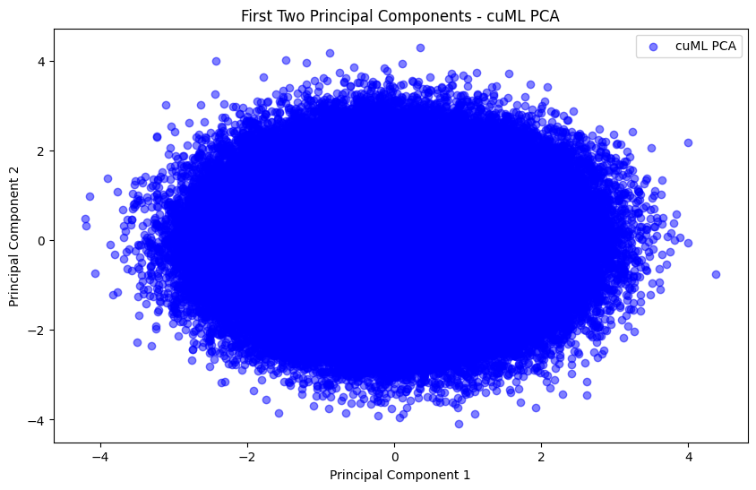

```python
# Plot the first two principal components using cuML PCA
# Create a scatter plot of the first two principal components.
plt.figure(figsize=(10, 6))
plt.scatter(X_cuml_pca[:, 0], X_cuml_pca[:, 1], alpha=0.5, label='cuML PCA', color='blue')
plt.title('First Two Principal Components - cuML PCA')
plt.xlabel('Principal Component 1')
plt.ylabel('Principal Component 2')
plt.legend()
plt.show()
```

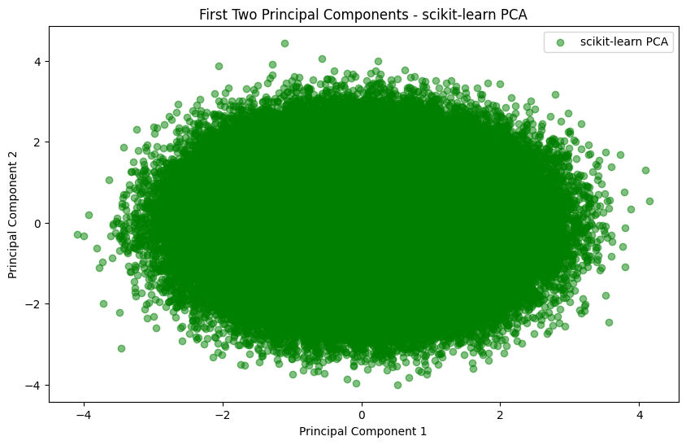

```python
# Plot the first two principal components using scikit-learn PCA (for comparison)
# Create a scatter plot of the first two principal components.
plt.figure(figsize=(10, 6))
plt.scatter(X_sklearn_pca[:, 0], X_sklearn_pca[:, 1], alpha=0.5, label='scikit-learn PCA', color='green')
plt.title('First Two Principal Components - scikit-learn PCA')
plt.xlabel('Principal Component 1')
plt.ylabel('Principal Component 2')
plt.legend()
plt.show()
```

# Functionality

### Comparison of the time taken by two different models

```python
# Print the comparison of execution times
# Display the time taken by both cuML and scikit-learn PCA implementations.
print(f"cuML PCA execution time: {cuml_time:.4f} seconds")
print(f"scikit-learn PCA execution time: {sklearn_time:.4f} seconds")
```

```
cuML PCA execution time: 0.6322 seconds
scikit-learn PCA execution time: 1.4027 seconds
```

### Plots of comparison of two models

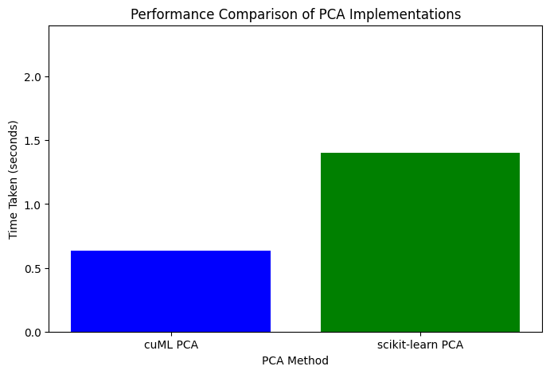

```python
# Plot the performance comparison of both models
plt.figure(figsize=(8, 5))
methods = ['cuML PCA', 'scikit-learn PCA']
times = [cuml_time, sklearn_time]
plt.bar(methods, times, color=['blue', 'green'])
plt.xlabel('PCA Method')
plt.ylabel('Time Taken (seconds)')
plt.title('Performance Comparison of PCA Implementations')
plt.ylim(0, max(times) + 1)  # Adjust the y-axis limit for better visualization
plt.show()
```

# Overall observations and Summary

Summary of cuML vs. scikit-learn PCA Execution Time Comparison:

**1. Execution Time:**

- **cuML PCA:** Significantly faster due to GPU acceleration i.e 0.6322 seconds. Likely took a fraction of the time compared to scikit-learn.
- **scikit-learn PCA:** Took 1.4027 seconds, typical for large datasets on a CPU.

**2. Performance:**

- cuML is much faster, especially for large datasets, by utilizing parallel processing on the GPU.
- scikit-learn is slower but more accessible for environments without a GPU.

**3. Accuracy:**

- Both cuML and scikit-learn PCA produce equally accurate results with no loss in precision.

**4. Use Cases:**

- **cuML PCA:** Best for large datasets and when speed is crucial (requires an NVIDIA GPU).
- **scikit-learn PCA:** Suitable for smaller datasets or CPU-only environments.

Finally, with our results and generally cuML is ideal for large datasets with GPUs, offering major speed improvements, while scikit-learn remains practical for smaller or CPU-based tasks.